# Statistical Rethinking

Chapter 2 notes

Dan Killian

1/13/2022

# 1 Two-way distributions

Let’s say we’re interested in joint and marginal probabilities of two variables, eye and hair color. Here’s a frequency table.

```r
freqs <- data.frame(eye_color=c("brown","blue","hazel","green","h"),
                    black = c(.11,.03,.03,.01,.18),
                    brunette = c(.2,.14,.09,.05,.48),
                    red = c(.04,.03,.02,.02,.12),
                    blond = c(.01,.16,.02,.03,.21),
                    e = c(.37,.36,.16,.11,1))

freqs
```

Table 1.1:

| eye_color | black | brunette | red | blond | e |
| --- | --- | --- | --- | --- | --- |
| brown | 0.11 | 0.2 | 0.04 | 0.01 | 0.37 |
| blue | 0.03 | 0.14 | 0.03 | 0.16 | 0.36 |
| hazel | 0.03 | 0.09 | 0.02 | 0.02 | 0.16 |
| green | 0.01 | 0.05 | 0.02 | 0.03 | 0.11 |
| h | 0.18 | 0.48 | 0.12 | 0.21 | 1 |

We denote the joint probability of eye color *e* and hair color *h* as $p(e,h)$, and note that $p(e, h) = p(h,e)$.

We obtain the marginal probabilities of hair or eye color by summing the joint probabilities across rows (eye color) or columns (hair color). We denote the marginal probability of eye color as $p(e)$ and hair color as $p(h)$, such that $p(e)=\sum_h{p(e,h)}$ and $p(h)=\sum_e{p(e,h)}$.

Generalizing this, consider a row variable *r* and column variable *c*. When the variables are continuous rather than discrete, then we take an integral rather than a sum. So, $p(r)=\int{dc\hspace{1mm} p(r,c)}$ and $p(c)=\int{dr\hspace{1mm}p(r,c)}$.

Suppose we know an individual has blue eyes. Conditional on that information, what are the probabilities for hair color? Blue-eyed individuals make up 36 percent of this sample. We divide the set of joint probabilities of blue eyes and each hair color by the marginal probability of blue eyes, we rescale the probabilities to sum to one, where one represents the sub-sample of people with blue eyes. These probabilities of hair color, conditional on blue eye color, can be denoted as $p(h|e=blue)=p(e=blue,h)/p(e=blue)$

```r
h_blue <- freqs[2,2:5] / freqs[2,6]

h_blue
```

Table 1.2:

| black | brunette | red | blond |
| --- | --- | --- | --- |
| 0.0833 | 0.389 | 0.0833 | 0.444 |

And these probabilities should sum to one.

```r
sum(h_blue)
```

```
## [1] 1
```

In general form, we say that $p(h|e)=p(e,h)/p(e)$ which can also be expressed as $p(h|e)=p(e,h)/\sum_hp(e,h*)$, where _h*_ denotes the full set of hair color values to sum over and *e* denotes a specific value of eye color. More generally, we can go back to the row and column variables:
$$p(c|r=x)=\frac{p(r=x,c)}{\sum_{c*}{p(r=x,c*)}}$$

Or:

$$p(c|r=x)=\frac{p(r=x,c)}{p(r=x)}$$
Or if you can maintain in your head that the conditioned variable takes on a definite value, we have:

$$p(c|r)=\frac{p(r,c)}{p(r)}$$
Again, just bearing in mind that the variable *r* takes on a specific value.

To get to Bayes Rule, multiply both sides of above by $p(r)$.
$$p(c|r)p(r)=p(r,c)$$

We can do the same thing with $p(r|c)$:

$p(r|c)=\frac{p(c,r)}{p(c)}$ and multiply both sides by $p(c)$

$$p(r|c)p(c)=p(c,r)$$

Recall the symmetry with joint probabilities $p(r,c)=p(c,r)$. We can then set the conditional expressions equal to each other.

$$p(c|r)p(r)=p(r|c)p(c)$$
Now divide by $p(r)$

# 2 2.1 Garden of forking data

Consider a bag containing four marbles that are either blue or white. We don’t know the color of each marble, but we know there could be five possibilities: (1) zero blue, (2) one blue, (3) two blue, (4) three blue, or (5) four blue. Consider each possibility as a conjecture about the actual state of the world. Without evidence, we can only assign equal probabilities to each conjecture, so 20 percent.

We take a marble from the bag, record its color, return it to the bag, and shake it up. We repeat this until we get three draws. The resulting sequence is blue, white, blue (b,w,b). This is sampling with replacement to produce data that can inform our conjectures.

Figure 2.2 in the text shows the garden of forking data - the enumeration of all possible paths the marble draws may take to produce the draw that was observed, conditional on each conjecture.

For conjecture (2) of one blue, there are three paths through the garden of forking data that produce our observed draw.

For conjecture (3) of two blue, there are eight paths through the garden of forking data.

## 2.1 From counts to probabilities

We multiply the number of ways the observed data could arise against the probability of each conjecture. We’ll call the probability of each conjecture the prior probability. With equal probability, the prior has no effect and we call the resulting operation the plausibility. The plausibilities for the set of conjectures are therefore 0, 3, 8, 9, 0. So three blue becomes our most likely conjecture, but only slightly more likely than the conjecture of two blue. We can call these plausibilities ‘likelihoods’.

More formally, let’s define the following:

> plausibility $\propto$ ways a conjecture can produce observed data $\times$ prior plausibility of the conjecture

Or more succintly:

Once we get the plausibilities of each conjecture, we normalize them in order to generate a set of probabilities.

```r
ways <- c(0,3,8,9,0)

ways / sum(ways) %>%
  round(3)
```

```
## [1] 0.00 0.15 0.40 0.45 0.00
```

# 3 2.2 Building a model

We made it through our first example! Which was designed to tortuously show you that Bayesian analysis is fundamentally just a counting procedure that arise from our assumptions. Given a set of assumptions, we simply compare what is possible.

Let’s proceed to the second example, which will be more like a real-world example.

```r
n_1 <- data.frame(prior=1,
                  param=round(seq(0,1,length.out=20),3)) %>%
  mutate(lik=dbinom(6,9,param))

n_1
```

Table 3.1:

| prior | param | lik |
| --- | --- | --- |
| 1 | 0 | 0 |
| 1 | 0.053 | 1.58e-06 |
| 1 | 0.105 | 8.07e-05 |
| 1 | 0.158 | 0.00078 |
| 1 | 0.211 | 0.00364 |
| 1 | 0.263 | 0.0111 |
| 1 | 0.316 | 0.0268 |
| 1 | 0.368 | 0.0527 |
| 1 | 0.421 | 0.0908 |
| 1 | 0.474 | 0.139 |
| 1 | 0.526 | 0.189 |
| 1 | 0.579 | 0.236 |
| 1 | 0.632 | 0.267 |
| 1 | 0.684 | 0.271 |
| 1 | 0.737 | 0.245 |
| 1 | 0.789 | 0.19 |
| 1 | 0.842 | 0.118 |
| 1 | 0.895 | 0.05 |
| 1 | 0.947 | 0.00902 |
| 1 | 1 | 0 |

```r
n_1 <- data.frame(toss=rep("w", 50),
                  trials=rep(1,50),
                  success=rep(1,50),
                  p_water = seq(0,1,length.out=50),
                  prior=rep(.02,50)) %>%
  mutate(lik_raw = dbinom(success,trials,p_water),
         lik=lik_raw / sum(lik_raw))

#,         prior2 = prior/sum(prior))
#sum(n_1$lik_raw) # 10 why?

n_1
```

Table 3.2:

| toss | trials | success | p_water | prior | lik_raw | lik |
| --- | --- | --- | --- | --- | --- | --- |
| w | 1 | 1 | 0 | 0.02 | 0 | 0 |
| w | 1 | 1 | 0.0204 | 0.02 | 0.0204 | 0.000816 |
| w | 1 | 1 | 0.0408 | 0.02 | 0.0408 | 0.00163 |
| w | 1 | 1 | 0.0612 | 0.02 | 0.0612 | 0.00245 |
| w | 1 | 1 | 0.0816 | 0.02 | 0.0816 | 0.00327 |
| w | 1 | 1 | 0.102 | 0.02 | 0.102 | 0.00408 |
| w | 1 | 1 | 0.122 | 0.02 | 0.122 | 0.0049 |
| w | 1 | 1 | 0.143 | 0.02 | 0.143 | 0.00571 |
| w | 1 | 1 | 0.163 | 0.02 | 0.163 | 0.00653 |
| w | 1 | 1 | 0.184 | 0.02 | 0.184 | 0.00735 |
| w | 1 | 1 | 0.204 | 0.02 | 0.204 | 0.00816 |
| w | 1 | 1 | 0.224 | 0.02 | 0.224 | 0.00898 |
| w | 1 | 1 | 0.245 | 0.02 | 0.245 | 0.0098 |
| w | 1 | 1 | 0.265 | 0.02 | 0.265 | 0.0106 |
| w | 1 | 1 | 0.286 | 0.02 | 0.286 | 0.0114 |
| w | 1 | 1 | 0.306 | 0.02 | 0.306 | 0.0122 |
| w | 1 | 1 | 0.327 | 0.02 | 0.327 | 0.0131 |
| w | 1 | 1 | 0.347 | 0.02 | 0.347 | 0.0139 |
| w | 1 | 1 | 0.367 | 0.02 | 0.367 | 0.0147 |
| w | 1 | 1 | 0.388 | 0.02 | 0.388 | 0.0155 |
| w | 1 | 1 | 0.408 | 0.02 | 0.408 | 0.0163 |
| w | 1 | 1 | 0.429 | 0.02 | 0.429 | 0.0171 |
| w | 1 | 1 | 0.449 | 0.02 | 0.449 | 0.018 |
| w | 1 | 1 | 0.469 | 0.02 | 0.469 | 0.0188 |
| w | 1 | 1 | 0.49 | 0.02 | 0.49 | 0.0196 |
| w | 1 | 1 | 0.51 | 0.02 | 0.51 | 0.0204 |
| w | 1 | 1 | 0.531 | 0.02 | 0.531 | 0.0212 |
| w | 1 | 1 | 0.551 | 0.02 | 0.551 | 0.022 |
| w | 1 | 1 | 0.571 | 0.02 | 0.571 | 0.0229 |
| w | 1 | 1 | 0.592 | 0.02 | 0.592 | 0.0237 |
| w | 1 | 1 | 0.612 | 0.02 | 0.612 | 0.0245 |
| w | 1 | 1 | 0.633 | 0.02 | 0.633 | 0.0253 |
| w | 1 | 1 | 0.653 | 0.02 | 0.653 | 0.0261 |
| w | 1 | 1 | 0.673 | 0.02 | 0.673 | 0.0269 |
| w | 1 | 1 | 0.694 | 0.02 | 0.694 | 0.0278 |
| w | 1 | 1 | 0.714 | 0.02 | 0.714 | 0.0286 |
| w | 1 | 1 | 0.735 | 0.02 | 0.735 | 0.0294 |
| w | 1 | 1 | 0.755 | 0.02 | 0.755 | 0.0302 |
| w | 1 | 1 | 0.776 | 0.02 | 0.776 | 0.031 |
| w | 1 | 1 | 0.796 | 0.02 | 0.796 | 0.0318 |
| w | 1 | 1 | 0.816 | 0.02 | 0.816 | 0.0327 |
| w | 1 | 1 | 0.837 | 0.02 | 0.837 | 0.0335 |
| w | 1 | 1 | 0.857 | 0.02 | 0.857 | 0.0343 |
| w | 1 | 1 | 0.878 | 0.02 | 0.878 | 0.0351 |
| w | 1 | 1 | 0.898 | 0.02 | 0.898 | 0.0359 |
| w | 1 | 1 | 0.918 | 0.02 | 0.918 | 0.0367 |
| w | 1 | 1 | 0.939 | 0.02 | 0.939 | 0.0376 |
| w | 1 | 1 | 0.959 | 0.02 | 0.959 | 0.0384 |
| w | 1 | 1 | 0.98 | 0.02 | 0.98 | 0.0392 |
| w | 1 | 1 | 1 | 0.02 | 1 | 0.04 |

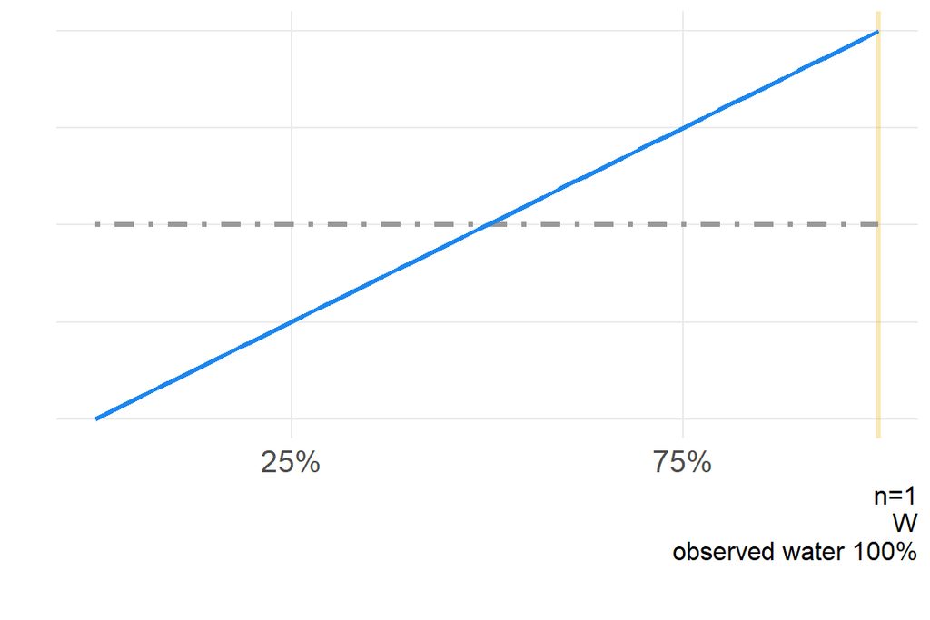

```r
n_1g <- ggplot(n_1, aes(p_water)) +
  geom_vline(xintercept=1, size=1.2, color="darkgoldenrod2", alpha=.3) +
  geom_line(aes(y=prior), size=1.2, color="grey60", linetype="dotdash") +
  geom_line(aes(y=lik), size=1, color="dodgerblue2") +
  scale_x_continuous(breaks=c(.25,.75),
                     labels=percent) +
  theme(axis.text.y=element_blank()) +
  labs(x="",
       y="",
       #title="W",
       caption="n=1\nW\nobserved water 100%") +
  theme(plot.caption = element_text(vjust=10))

n_1g
```

```r
d
```

```
## Error in eval(expr, envir, enclos): object 'd' not found
```

```r
n_2 <- data.frame(toss=rep("l", 50),
                  trials=rep(2,50),
                  success=rep(1,50),
                  p_water = seq(0,1,length.out=50),
                  prior=n_1$lik) %>%
  mutate(lik_raw = dbinom(success,trials,p_water),
         lik=lik_raw / sum(lik_raw))

n_2
```

Table 3.2:

| toss | trials | success | p_water | prior | lik_raw | lik |
| --- | --- | --- | --- | --- | --- | --- |
| l | 2 | 1 | 0 | 0 | 0 | 0 |
| l | 2 | 1 | 0.0204 | 0.000816 | 0.04 | 0.00245 |
| l | 2 | 1 | 0.0408 | 0.00163 | 0.0783 | 0.0048 |
| l | 2 | 1 | 0.0612 | 0.00245 | 0.115 | 0.00704 |
| l | 2 | 1 | 0.0816 | 0.00327 | 0.15 | 0.00918 |
| l | 2 | 1 | 0.102 | 0.00408 | 0.183 | 0.0112 |
| l | 2 | 1 | 0.122 | 0.0049 | 0.215 | 0.0132 |
| l | 2 | 1 | 0.143 | 0.00571 | 0.245 | 0.015 |
| l | 2 | 1 | 0.163 | 0.00653 | 0.273 | 0.0167 |
| l | 2 | 1 | 0.184 | 0.00735 | 0.3 | 0.0184 |
| l | 2 | 1 | 0.204 | 0.00816 | 0.325 | 0.0199 |
| l | 2 | 1 | 0.224 | 0.00898 | 0.348 | 0.0213 |
| l | 2 | 1 | 0.245 | 0.0098 | 0.37 | 0.0227 |
| l | 2 | 1 | 0.265 | 0.0106 | 0.39 | 0.0239 |
| l | 2 | 1 | 0.286 | 0.0114 | 0.408 | 0.025 |
| l | 2 | 1 | 0.306 | 0.0122 | 0.425 | 0.026 |
| l | 2 | 1 | 0.327 | 0.0131 | 0.44 | 0.0269 |
| l | 2 | 1 | 0.347 | 0.0139 | 0.453 | 0.0278 |
| l | 2 | 1 | 0.367 | 0.0147 | 0.465 | 0.0285 |
| l | 2 | 1 | 0.388 | 0.0155 | 0.475 | 0.0291 |
| l | 2 | 1 | 0.408 | 0.0163 | 0.483 | 0.0296 |
| l | 2 | 1 | 0.429 | 0.0171 | 0.49 | 0.03 |
| l | 2 | 1 | 0.449 | 0.018 | 0.495 | 0.0303 |
| l | 2 | 1 | 0.469 | 0.0188 | 0.498 | 0.0305 |
| l | 2 | 1 | 0.49 | 0.0196 | 0.5 | 0.0306 |
| l | 2 | 1 | 0.51 | 0.0204 | 0.5 | 0.0306 |
| l | 2 | 1 | 0.531 | 0.0212 | 0.498 | 0.0305 |
| l | 2 | 1 | 0.551 | 0.022 | 0.495 | 0.0303 |
| l | 2 | 1 | 0.571 | 0.0229 | 0.49 | 0.03 |
| l | 2 | 1 | 0.592 | 0.0237 | 0.483 | 0.0296 |
| l | 2 | 1 | 0.612 | 0.0245 | 0.475 | 0.0291 |
| l | 2 | 1 | 0.633 | 0.0253 | 0.465 | 0.0285 |
| l | 2 | 1 | 0.653 | 0.0261 | 0.453 | 0.0278 |
| l | 2 | 1 | 0.673 | 0.0269 | 0.44 | 0.0269 |
| l | 2 | 1 | 0.694 | 0.0278 | 0.425 | 0.026 |
| l | 2 | 1 | 0.714 | 0.0286 | 0.408 | 0.025 |
| l | 2 | 1 | 0.735 | 0.0294 | 0.39 | 0.0239 |
| l | 2 | 1 | 0.755 | 0.0302 | 0.37 | 0.0227 |
| l | 2 | 1 | 0.776 | 0.031 | 0.348 | 0.0213 |
| l | 2 | 1 | 0.796 | 0.0318 | 0.325 | 0.0199 |
| l | 2 | 1 | 0.816 | 0.0327 | 0.3 | 0.0184 |
| l | 2 | 1 | 0.837 | 0.0335 | 0.273 | 0.0167 |
| l | 2 | 1 | 0.857 | 0.0343 | 0.245 | 0.015 |
| l | 2 | 1 | 0.878 | 0.0351 | 0.215 | 0.0132 |
| l | 2 | 1 | 0.898 | 0.0359 | 0.183 | 0.0112 |
| l | 2 | 1 | 0.918 | 0.0367 | 0.15 | 0.00918 |
| l | 2 | 1 | 0.939 | 0.0376 | 0.115 | 0.00704 |
| l | 2 | 1 | 0.959 | 0.0384 | 0.0783 | 0.0048 |
| l | 2 | 1 | 0.98 | 0.0392 | 0.04 | 0.00245 |
| l | 2 | 1 | 1 | 0.04 | 0 | 0 |

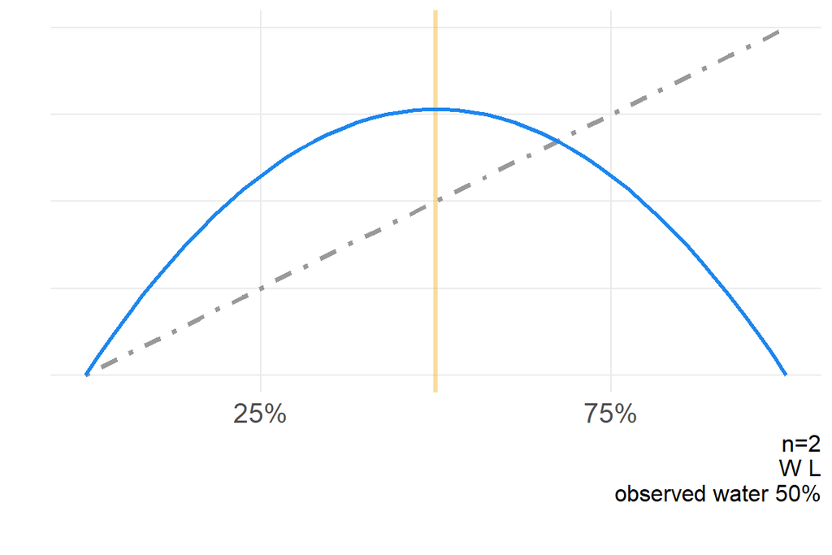

```r
n_2g <- ggplot(n_2, aes(p_water)) +
  geom_vline(xintercept=.5, size=1.2, color="darkgoldenrod2", alpha=.4) +
  geom_line(aes(y=prior), size=1.2, color="grey60", linetype="dotdash") +
  geom_line(aes(y=lik), size=1, color="dodgerblue2") +
  scale_x_continuous(breaks=c(.25,.75),
                     labels=percent) +
  theme(axis.text.y=element_blank()) +
  labs(x="",
       y="",
       #title="W L",
       caption="n=2\nW L\nobserved water 50%") +
  theme(plot.caption = element_text(vjust=10))

n_2g
```

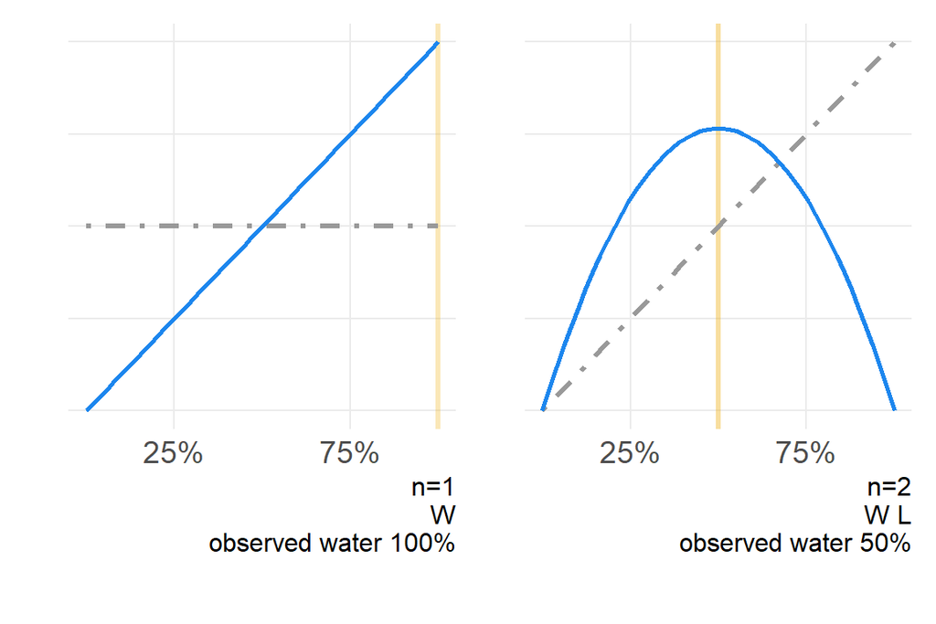

```r
library(patchwork)
n_1g + n_2g
```

```r
d
```

```
## Error in eval(expr, envir, enclos): object 'd' not found
```

```r
n_3 <- data.frame(toss=rep("w", 50),
                  trials=rep(3,50),
                  success=rep(2,50),
                  p_water = seq(0,1,length.out=50),
                  prior=n_2$lik) %>%
  mutate(lik_raw = dbinom(success,trials,p_water),
         lik=lik_raw / sum(lik_raw))

n_3
```

Table 3.2:

| toss | trials | success | p_water | prior | lik_raw | lik |
| --- | --- | --- | --- | --- | --- | --- |
| w | 3 | 2 | 0 | 0 | 0 | 0 |
| w | 3 | 2 | 0.0204 | 0.00245 | 0.00122 | 1e-04 |
| w | 3 | 2 | 0.0408 | 0.0048 | 0.00479 | 0.000392 |
| w | 3 | 2 | 0.0612 | 0.00704 | 0.0106 | 0.000862 |
| w | 3 | 2 | 0.0816 | 0.00918 | 0.0184 | 0.0015 |
| w | 3 | 2 | 0.102 | 0.0112 | 0.028 | 0.00229 |
| w | 3 | 2 | 0.122 | 0.0132 | 0.0395 | 0.00322 |
| w | 3 | 2 | 0.143 | 0.015 | 0.0525 | 0.00429 |
| w | 3 | 2 | 0.163 | 0.0167 | 0.0669 | 0.00546 |
| w | 3 | 2 | 0.184 | 0.0184 | 0.0826 | 0.00675 |
| w | 3 | 2 | 0.204 | 0.0199 | 0.0994 | 0.00812 |
| w | 3 | 2 | 0.224 | 0.0213 | 0.117 | 0.00958 |
| w | 3 | 2 | 0.245 | 0.0227 | 0.136 | 0.0111 |
| w | 3 | 2 | 0.265 | 0.0239 | 0.155 | 0.0127 |
| w | 3 | 2 | 0.286 | 0.025 | 0.175 | 0.0143 |
| w | 3 | 2 | 0.306 | 0.026 | 0.195 | 0.0159 |
| w | 3 | 2 | 0.327 | 0.0269 | 0.215 | 0.0176 |
| w | 3 | 2 | 0.347 | 0.0278 | 0.236 | 0.0193 |
| w | 3 | 2 | 0.367 | 0.0285 | 0.256 | 0.0209 |
| w | 3 | 2 | 0.388 | 0.0291 | 0.276 | 0.0226 |
| w | 3 | 2 | 0.408 | 0.0296 | 0.296 | 0.0242 |
| w | 3 | 2 | 0.429 | 0.03 | 0.315 | 0.0257 |
| w | 3 | 2 | 0.449 | 0.0303 | 0.333 | 0.0272 |
| w | 3 | 2 | 0.469 | 0.0305 | 0.351 | 0.0286 |
| w | 3 | 2 | 0.49 | 0.0306 | 0.367 | 0.03 |
| w | 3 | 2 | 0.51 | 0.0306 | 0.382 | 0.0312 |
| w | 3 | 2 | 0.531 | 0.0305 | 0.396 | 0.0324 |
| w | 3 | 2 | 0.551 | 0.0303 | 0.409 | 0.0334 |
| w | 3 | 2 | 0.571 | 0.03 | 0.42 | 0.0343 |
| w | 3 | 2 | 0.592 | 0.0296 | 0.429 | 0.035 |
| w | 3 | 2 | 0.612 | 0.0291 | 0.436 | 0.0356 |
| w | 3 | 2 | 0.633 | 0.0285 | 0.441 | 0.036 |
| w | 3 | 2 | 0.653 | 0.0278 | 0.444 | 0.0363 |
| w | 3 | 2 | 0.673 | 0.0269 | 0.444 | 0.0363 |
| w | 3 | 2 | 0.694 | 0.026 | 0.442 | 0.0361 |
| w | 3 | 2 | 0.714 | 0.025 | 0.437 | 0.0357 |
| w | 3 | 2 | 0.735 | 0.0239 | 0.43 | 0.0351 |
| w | 3 | 2 | 0.755 | 0.0227 | 0.419 | 0.0342 |
| w | 3 | 2 | 0.776 | 0.0213 | 0.405 | 0.0331 |
| w | 3 | 2 | 0.796 | 0.0199 | 0.388 | 0.0317 |
| w | 3 | 2 | 0.816 | 0.0184 | 0.367 | 0.03 |
| w | 3 | 2 | 0.837 | 0.0167 | 0.343 | 0.028 |
| w | 3 | 2 | 0.857 | 0.015 | 0.315 | 0.0257 |
| w | 3 | 2 | 0.878 | 0.0132 | 0.283 | 0.0231 |
| w | 3 | 2 | 0.898 | 0.0112 | 0.247 | 0.0202 |
| w | 3 | 2 | 0.918 | 0.00918 | 0.207 | 0.0169 |
| w | 3 | 2 | 0.939 | 0.00704 | 0.162 | 0.0132 |
| w | 3 | 2 | 0.959 | 0.0048 | 0.113 | 0.0092 |
| w | 3 | 2 | 0.98 | 0.00245 | 0.0588 | 0.0048 |
| w | 3 | 2 | 1 | 0 | 0 | 0 |

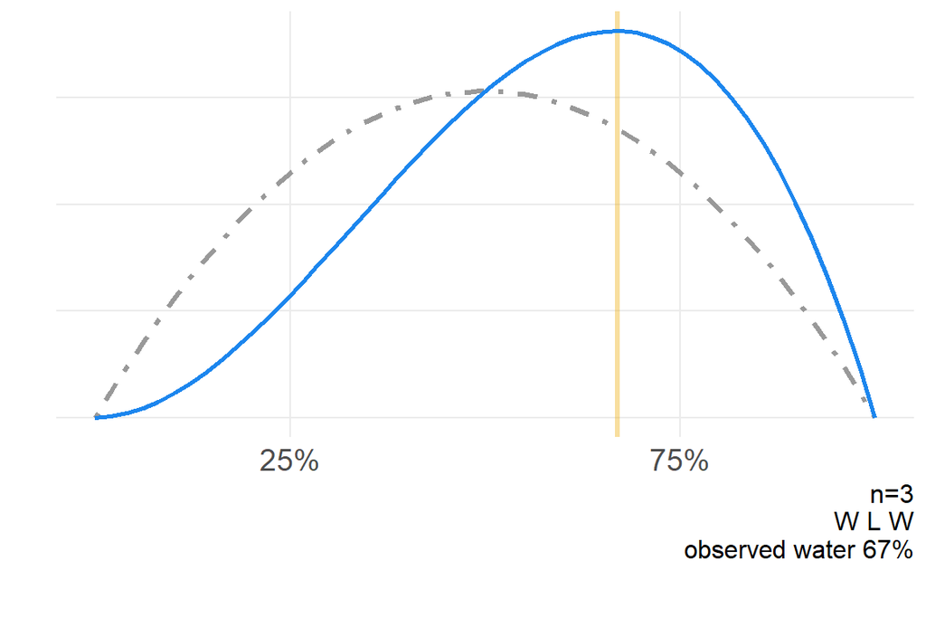

```r
n_3g <- ggplot(n_3, aes(p_water)) +
  geom_vline(xintercept=.67, size=1.2, color="darkgoldenrod2", alpha=.4) +
  geom_line(aes(y=prior), size=1.2, color="grey60", linetype="dotdash") +
  geom_line(aes(y=lik), size=1, color="dodgerblue2") +
  scale_x_continuous(breaks=c(.25,.75),
                     labels=percent) +
  theme(axis.text.y=element_blank()) +
  labs(x="",
       y="",
       #title="W L W",
       caption="n=3\nW L W\nobserved water 67%") +
  theme(plot.caption = element_text(vjust=10))

n_3g
```

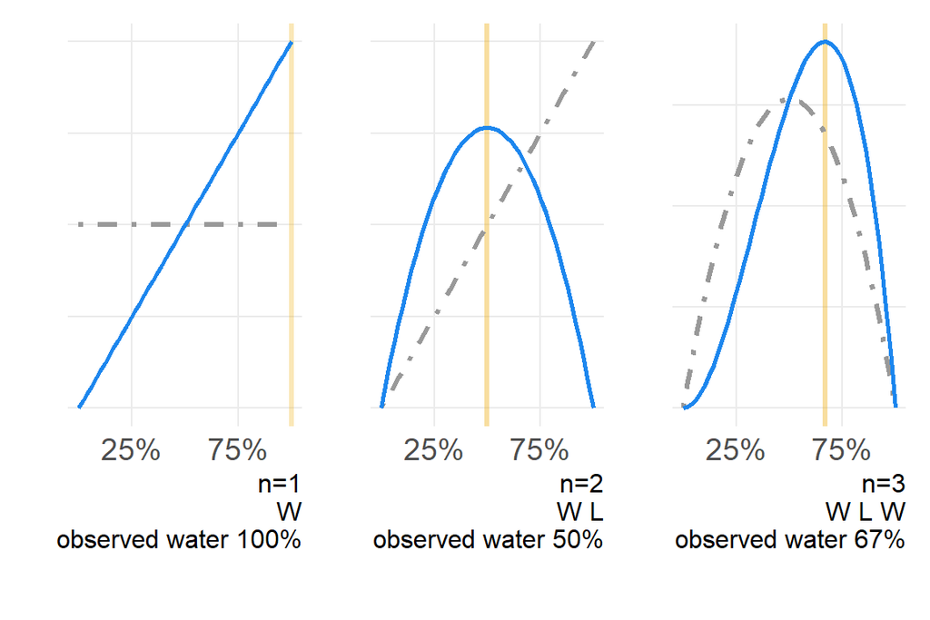

```r
n_1g + n_2g + n_3g
```

```r
d
```

```
## Error in eval(expr, envir, enclos): object 'd' not found
```

```r
n_4 <- data.frame(toss=rep("w", 50),
                  trials=rep(4,50),
                  success=rep(3,50),
                  p_water = seq(0,1,length.out=50),
                  prior=n_3$lik) %>%
  mutate(lik_raw = dbinom(success,trials,p_water),
         lik=lik_raw / sum(lik_raw))

n_4
```

Table 3.2:

| toss | trials | success | p_water | prior | lik_raw | lik |
| --- | --- | --- | --- | --- | --- | --- |
| w | 4 | 3 | 0 | 0 | 0 | 0 |
| w | 4 | 3 | 0.0204 | 1e-04 | 3.33e-05 | 3.4e-06 |
| w | 4 | 3 | 0.0408 | 0.000392 | 0.000261 | 2.66e-05 |
| w | 4 | 3 | 0.0612 | 0.000862 | 0.000862 | 8.8e-05 |
| w | 4 | 3 | 0.0816 | 0.0015 | 0.002 | 0.000204 |
| w | 4 | 3 | 0.102 | 0.00229 | 0.00382 | 0.00039 |
| w | 4 | 3 | 0.122 | 0.00322 | 0.00644 | 0.000658 |
| w | 4 | 3 | 0.143 | 0.00429 | 0.01 | 0.00102 |
| w | 4 | 3 | 0.163 | 0.00546 | 0.0146 | 0.00149 |
| w | 4 | 3 | 0.184 | 0.00675 | 0.0202 | 0.00207 |
| w | 4 | 3 | 0.204 | 0.00812 | 0.0271 | 0.00276 |
| w | 4 | 3 | 0.224 | 0.00958 | 0.0351 | 0.00358 |
| w | 4 | 3 | 0.245 | 0.0111 | 0.0444 | 0.00453 |
| w | 4 | 3 | 0.265 | 0.0127 | 0.0549 | 0.0056 |
| w | 4 | 3 | 0.286 | 0.0143 | 0.0666 | 0.0068 |
| w | 4 | 3 | 0.306 | 0.0159 | 0.0796 | 0.00813 |
| w | 4 | 3 | 0.327 | 0.0176 | 0.0938 | 0.00958 |
| w | 4 | 3 | 0.347 | 0.0193 | 0.109 | 0.0111 |
| w | 4 | 3 | 0.367 | 0.0209 | 0.125 | 0.0128 |
| w | 4 | 3 | 0.388 | 0.0226 | 0.143 | 0.0146 |
| w | 4 | 3 | 0.408 | 0.0242 | 0.161 | 0.0164 |
| w | 4 | 3 | 0.429 | 0.0257 | 0.18 | 0.0184 |
| w | 4 | 3 | 0.449 | 0.0272 | 0.199 | 0.0204 |
| w | 4 | 3 | 0.469 | 0.0286 | 0.219 | 0.0224 |
| w | 4 | 3 | 0.49 | 0.03 | 0.24 | 0.0245 |
| w | 4 | 3 | 0.51 | 0.0312 | 0.26 | 0.0266 |
| w | 4 | 3 | 0.531 | 0.0324 | 0.28 | 0.0286 |
| w | 4 | 3 | 0.551 | 0.0334 | 0.3 | 0.0307 |
| w | 4 | 3 | 0.571 | 0.0343 | 0.32 | 0.0327 |
| w | 4 | 3 | 0.592 | 0.035 | 0.338 | 0.0346 |
| w | 4 | 3 | 0.612 | 0.0356 | 0.356 | 0.0363 |
| w | 4 | 3 | 0.633 | 0.036 | 0.372 | 0.038 |
| w | 4 | 3 | 0.653 | 0.0363 | 0.387 | 0.0395 |
| w | 4 | 3 | 0.673 | 0.0363 | 0.399 | 0.0407 |
| w | 4 | 3 | 0.694 | 0.0361 | 0.409 | 0.0418 |
| w | 4 | 3 | 0.714 | 0.0357 | 0.416 | 0.0425 |
| w | 4 | 3 | 0.735 | 0.0351 | 0.421 | 0.043 |
| w | 4 | 3 | 0.755 | 0.0342 | 0.422 | 0.0431 |
| w | 4 | 3 | 0.776 | 0.0331 | 0.419 | 0.0428 |
| w | 4 | 3 | 0.796 | 0.0317 | 0.412 | 0.042 |
| w | 4 | 3 | 0.816 | 0.03 | 0.4 | 0.0408 |
| w | 4 | 3 | 0.837 | 0.028 | 0.383 | 0.0391 |
| w | 4 | 3 | 0.857 | 0.0257 | 0.36 | 0.0367 |
| w | 4 | 3 | 0.878 | 0.0231 | 0.331 | 0.0338 |
| w | 4 | 3 | 0.898 | 0.0202 | 0.296 | 0.0302 |
| w | 4 | 3 | 0.918 | 0.0169 | 0.253 | 0.0258 |
| w | 4 | 3 | 0.939 | 0.0132 | 0.203 | 0.0207 |
| w | 4 | 3 | 0.959 | 0.0092 | 0.144 | 0.0147 |
| w | 4 | 3 | 0.98 | 0.0048 | 0.0767 | 0.00784 |
| w | 4 | 3 | 1 | 0 | 0 | 0 |

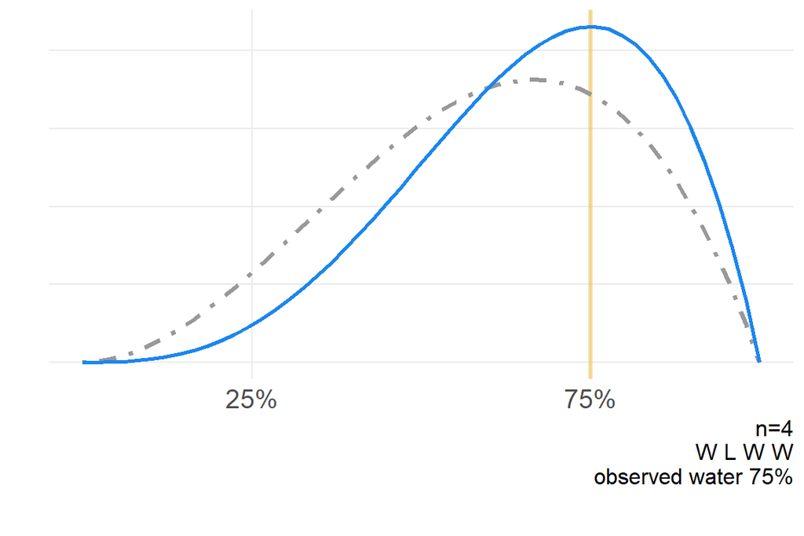

```r
n_4g <- ggplot(n_4, aes(p_water)) +
  geom_vline(xintercept=.75, size=1.2, color="darkgoldenrod2", alpha=.4) +
  geom_line(aes(y=prior), size=1.2, color="grey60", linetype="dotdash") +
  geom_line(aes(y=lik), size=1, color="dodgerblue2") +
  scale_x_continuous(breaks=c(.25,.75),
                     labels=percent) +
  theme(axis.text.y=element_blank()) +
  labs(x="",
       y="",
       #title="W L W W",
       caption="n=4\nW L W W\nobserved water 75%") +
  theme(plot.caption = element_text(vjust=10))

n_4g
```

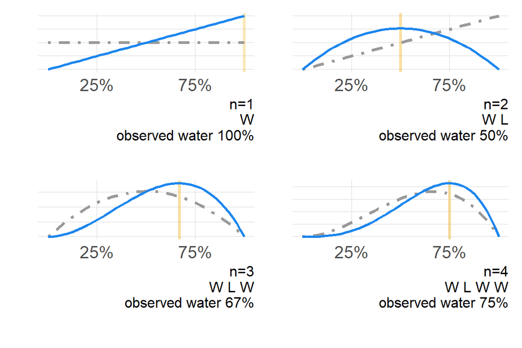

```r
n_1g + n_2g + n_3g + n_4g
```

```r
d
```

```
## Error in eval(expr, envir, enclos): object 'd' not found
```

```r
n_5 <- data.frame(toss=rep("w", 50),
                  trials=rep(5,50),
                  success=rep(4,50),
                  p_water = seq(0,1,length.out=50),
                  prior=n_4$lik) %>%
  mutate(lik_raw = dbinom(success,trials,p_water),
         lik=lik_raw / sum(lik_raw))

n_5
```

Table 3.2:

| toss | trials | success | p_water | prior | lik_raw | lik |
| --- | --- | --- | --- | --- | --- | --- |
| w | 5 | 4 | 0 | 0 | 0 | 0 |
| w | 5 | 4 | 0.0204 | 3.4e-06 | 8.5e-07 | 1.04e-07 |
| w | 5 | 4 | 0.0408 | 2.66e-05 | 1.33e-05 | 1.63e-06 |
| w | 5 | 4 | 0.0612 | 8.8e-05 | 6.6e-05 | 8.08e-06 |
| w | 5 | 4 | 0.0816 | 0.000204 | 0.000204 | 2.5e-05 |
| w | 5 | 4 | 0.102 | 0.00039 | 0.000487 | 5.97e-05 |
| w | 5 | 4 | 0.122 | 0.000658 | 0.000986 | 0.000121 |
| w | 5 | 4 | 0.143 | 0.00102 | 0.00178 | 0.000219 |
| w | 5 | 4 | 0.163 | 0.00149 | 0.00297 | 0.000364 |
| w | 5 | 4 | 0.184 | 0.00207 | 0.00465 | 0.000569 |
| w | 5 | 4 | 0.204 | 0.00276 | 0.0069 | 0.000846 |
| w | 5 | 4 | 0.224 | 0.00358 | 0.00985 | 0.00121 |
| w | 5 | 4 | 0.245 | 0.00453 | 0.0136 | 0.00166 |
| w | 5 | 4 | 0.265 | 0.0056 | 0.0182 | 0.00223 |
| w | 5 | 4 | 0.286 | 0.0068 | 0.0238 | 0.00292 |
| w | 5 | 4 | 0.306 | 0.00813 | 0.0305 | 0.00373 |
| w | 5 | 4 | 0.327 | 0.00958 | 0.0383 | 0.00469 |
| w | 5 | 4 | 0.347 | 0.0111 | 0.0473 | 0.0058 |
| w | 5 | 4 | 0.367 | 0.0128 | 0.0576 | 0.00706 |
| w | 5 | 4 | 0.388 | 0.0146 | 0.0692 | 0.00848 |
| w | 5 | 4 | 0.408 | 0.0164 | 0.0821 | 0.0101 |
| w | 5 | 4 | 0.429 | 0.0184 | 0.0964 | 0.0118 |
| w | 5 | 4 | 0.449 | 0.0204 | 0.112 | 0.0137 |
| w | 5 | 4 | 0.469 | 0.0224 | 0.129 | 0.0158 |
| w | 5 | 4 | 0.49 | 0.0245 | 0.147 | 0.018 |
| w | 5 | 4 | 0.51 | 0.0266 | 0.166 | 0.0203 |
| w | 5 | 4 | 0.531 | 0.0286 | 0.186 | 0.0228 |
| w | 5 | 4 | 0.551 | 0.0307 | 0.207 | 0.0254 |
| w | 5 | 4 | 0.571 | 0.0327 | 0.228 | 0.028 |
| w | 5 | 4 | 0.592 | 0.0346 | 0.25 | 0.0307 |
| w | 5 | 4 | 0.612 | 0.0363 | 0.272 | 0.0334 |
| w | 5 | 4 | 0.633 | 0.038 | 0.294 | 0.0361 |
| w | 5 | 4 | 0.653 | 0.0395 | 0.316 | 0.0387 |
| w | 5 | 4 | 0.673 | 0.0407 | 0.336 | 0.0412 |
| w | 5 | 4 | 0.694 | 0.0418 | 0.355 | 0.0435 |
| w | 5 | 4 | 0.714 | 0.0425 | 0.372 | 0.0456 |
| w | 5 | 4 | 0.735 | 0.043 | 0.386 | 0.0474 |
| w | 5 | 4 | 0.755 | 0.0431 | 0.398 | 0.0488 |
| w | 5 | 4 | 0.776 | 0.0428 | 0.406 | 0.0498 |
| w | 5 | 4 | 0.796 | 0.042 | 0.409 | 0.0502 |
| w | 5 | 4 | 0.816 | 0.0408 | 0.408 | 0.05 |
| w | 5 | 4 | 0.837 | 0.0391 | 0.4 | 0.049 |
| w | 5 | 4 | 0.857 | 0.0367 | 0.386 | 0.0473 |
| w | 5 | 4 | 0.878 | 0.0338 | 0.363 | 0.0445 |
| w | 5 | 4 | 0.898 | 0.0302 | 0.332 | 0.0407 |
| w | 5 | 4 | 0.918 | 0.0258 | 0.29 | 0.0356 |
| w | 5 | 4 | 0.939 | 0.0207 | 0.238 | 0.0291 |
| w | 5 | 4 | 0.959 | 0.0147 | 0.173 | 0.0212 |
| w | 5 | 4 | 0.98 | 0.00784 | 0.094 | 0.0115 |
| w | 5 | 4 | 1 | 0 | 0 | 0 |

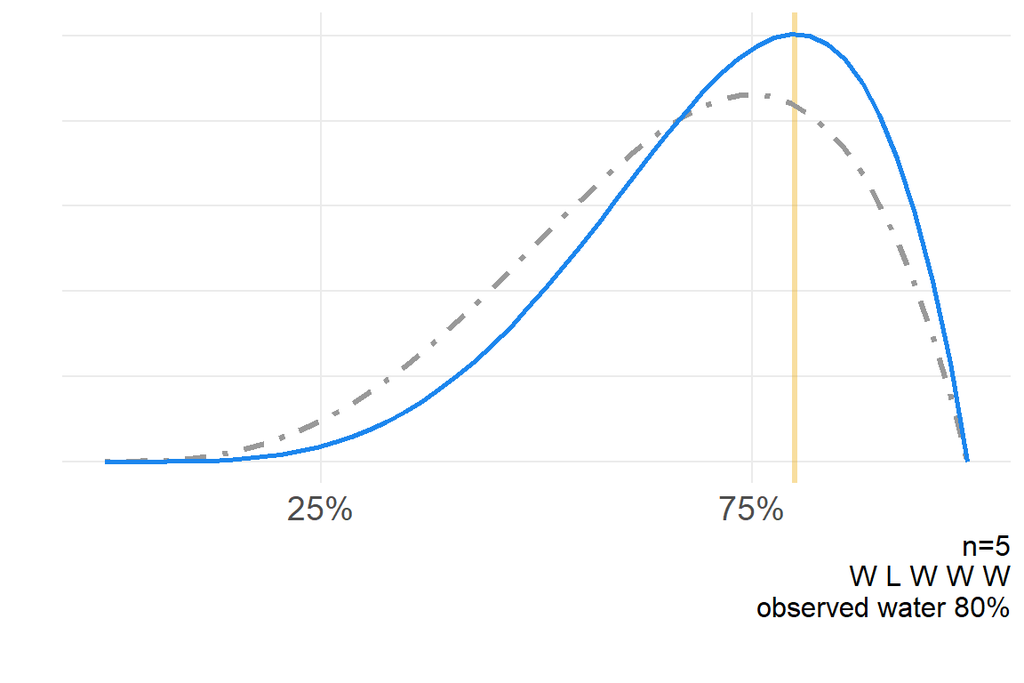

```r
n_5g <- ggplot(n_5, aes(p_water)) +
  geom_vline(xintercept=.8, size=1.2, color="darkgoldenrod2", alpha=.4) +
  geom_line(aes(y=prior), size=1.2, color="grey60", linetype="dotdash") +
  geom_line(aes(y=lik), size=1, color="dodgerblue2") +
  scale_x_continuous(breaks=c(.25,.75),
                     labels=percent) +
  theme(axis.text.y=element_blank()) +
  labs(x="",
       y="",
       #title="W L W W W",
       caption="n=5\nW L W W W\nobserved water 80%") +
  theme(plot.caption = element_text(vjust=10))

n_5g
```

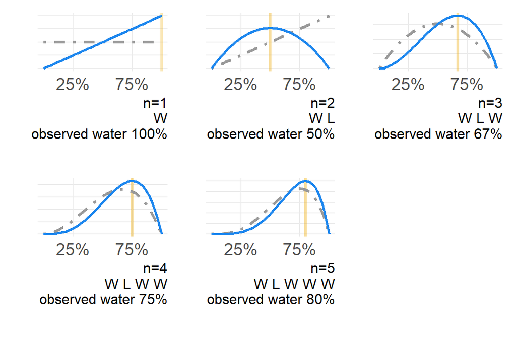

```r
n_1g + n_2g + n_3g + n_4g + n_5g
```

```r
d
```

```
## Error in eval(expr, envir, enclos): object 'd' not found
```

```r
n_6 <- data.frame(toss=rep("l", 50),
                  trials=rep(6,50),
                  success=rep(4,50),
                  p_water = seq(0,1,length.out=50),
                  prior=n_5$lik) %>%
  mutate(lik_raw = dbinom(success,trials,p_water),
         lik=lik_raw / sum(lik_raw))

n_6
```

Table 3.2:

| toss | trials | success | p_water | prior | lik_raw | lik |
| --- | --- | --- | --- | --- | --- | --- |
| l | 6 | 4 | 0 | 0 | 0 | 0 |
| l | 6 | 4 | 0.0204 | 1.04e-07 | 2.5e-06 | 3.57e-07 |
| l | 6 | 4 | 0.0408 | 1.63e-06 | 3.83e-05 | 5.47e-06 |
| l | 6 | 4 | 0.0612 | 8.08e-06 | 0.000186 | 2.65e-05 |
| l | 6 | 4 | 0.0816 | 2.5e-05 | 0.000562 | 8.03e-05 |
| l | 6 | 4 | 0.102 | 5.97e-05 | 0.00131 | 0.000187 |
| l | 6 | 4 | 0.122 | 0.000121 | 0.0026 | 0.000371 |
| l | 6 | 4 | 0.143 | 0.000219 | 0.00459 | 0.000656 |
| l | 6 | 4 | 0.163 | 0.000364 | 0.00746 | 0.00107 |
| l | 6 | 4 | 0.184 | 0.000569 | 0.0114 | 0.00163 |
| l | 6 | 4 | 0.204 | 0.000846 | 0.0165 | 0.00235 |
| l | 6 | 4 | 0.224 | 0.00121 | 0.0229 | 0.00327 |
| l | 6 | 4 | 0.245 | 0.00166 | 0.0308 | 0.00439 |
| l | 6 | 4 | 0.265 | 0.00223 | 0.0401 | 0.00573 |
| l | 6 | 4 | 0.286 | 0.00292 | 0.051 | 0.00729 |
| l | 6 | 4 | 0.306 | 0.00373 | 0.0634 | 0.00906 |
| l | 6 | 4 | 0.327 | 0.00469 | 0.0773 | 0.011 |
| l | 6 | 4 | 0.347 | 0.0058 | 0.0927 | 0.0132 |
| l | 6 | 4 | 0.367 | 0.00706 | 0.109 | 0.0156 |
| l | 6 | 4 | 0.388 | 0.00848 | 0.127 | 0.0182 |
| l | 6 | 4 | 0.408 | 0.0101 | 0.146 | 0.0208 |
| l | 6 | 4 | 0.429 | 0.0118 | 0.165 | 0.0236 |
| l | 6 | 4 | 0.449 | 0.0137 | 0.185 | 0.0264 |
| l | 6 | 4 | 0.469 | 0.0158 | 0.205 | 0.0293 |
| l | 6 | 4 | 0.49 | 0.018 | 0.225 | 0.0321 |
| l | 6 | 4 | 0.51 | 0.0203 | 0.244 | 0.0348 |
| l | 6 | 4 | 0.531 | 0.0228 | 0.262 | 0.0374 |
| l | 6 | 4 | 0.551 | 0.0254 | 0.279 | 0.0398 |
| l | 6 | 4 | 0.571 | 0.028 | 0.294 | 0.042 |
| l | 6 | 4 | 0.592 | 0.0307 | 0.307 | 0.0438 |
| l | 6 | 4 | 0.612 | 0.0334 | 0.317 | 0.0453 |
| l | 6 | 4 | 0.633 | 0.0361 | 0.324 | 0.0463 |
| l | 6 | 4 | 0.653 | 0.0387 | 0.328 | 0.0469 |
| l | 6 | 4 | 0.673 | 0.0412 | 0.329 | 0.047 |
| l | 6 | 4 | 0.694 | 0.0435 | 0.326 | 0.0465 |
| l | 6 | 4 | 0.714 | 0.0456 | 0.319 | 0.0455 |
| l | 6 | 4 | 0.735 | 0.0474 | 0.308 | 0.0439 |
| l | 6 | 4 | 0.755 | 0.0488 | 0.292 | 0.0418 |
| l | 6 | 4 | 0.776 | 0.0498 | 0.273 | 0.0391 |
| l | 6 | 4 | 0.796 | 0.0502 | 0.251 | 0.0358 |
| l | 6 | 4 | 0.816 | 0.05 | 0.225 | 0.0321 |
| l | 6 | 4 | 0.837 | 0.049 | 0.196 | 0.028 |
| l | 6 | 4 | 0.857 | 0.0473 | 0.165 | 0.0236 |
| l | 6 | 4 | 0.878 | 0.0445 | 0.133 | 0.0191 |
| l | 6 | 4 | 0.898 | 0.0407 | 0.102 | 0.0145 |
| l | 6 | 4 | 0.918 | 0.0356 | 0.0711 | 0.0102 |
| l | 6 | 4 | 0.939 | 0.0291 | 0.0437 | 0.00624 |
| l | 6 | 4 | 0.959 | 0.0212 | 0.0212 | 0.00302 |
| l | 6 | 4 | 0.98 | 0.0115 | 0.00575 | 0.000822 |
| l | 6 | 4 | 1 | 0 | 0 | 0 |

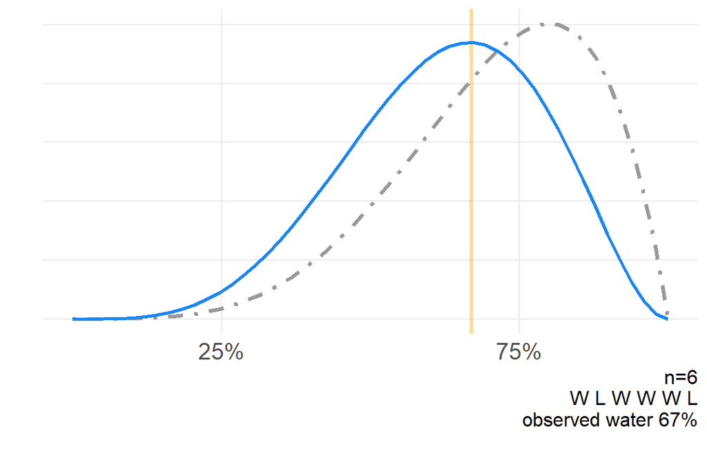

```r
n_6g <- ggplot(n_6, aes(p_water)) +
  geom_vline(xintercept=.67, size=1.2, color="darkgoldenrod2", alpha=.4) +
  geom_line(aes(y=prior), size=1.2, color="grey60", linetype="dotdash") +
  geom_line(aes(y=lik), size=1, color="dodgerblue2") +
  scale_x_continuous(breaks=c(.25,.75),
                     labels=percent) +
  theme(axis.text.y=element_blank()) +
  labs(x="",
       y="",
       #title="W L W W W L",
       caption="n=6\nW L W W W L\nobserved water 67%") +
  theme(plot.caption = element_text(vjust=10))

n_6g
```

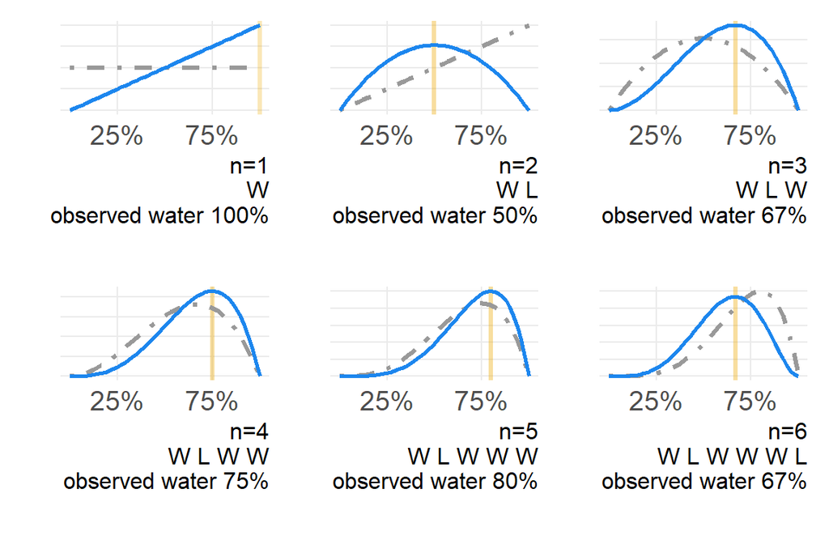

```r
n_1g + n_2g + n_3g + n_4g + n_5g + n_6g
```

```r
d
```

```
## Error in eval(expr, envir, enclos): object 'd' not found
```

```r
n_7 <- data.frame(toss=rep("w", 50),
                  trials=rep(7,50),
                  success=rep(5,50),
                  p_water = seq(0,1,length.out=50),
                  prior=n_6$lik) %>%
  mutate(lik_raw = dbinom(success,trials,p_water),
         lik=lik_raw / sum(lik_raw))

n_7
```

Table 3.2:

| toss | trials | success | p_water | prior | lik_raw | lik |
| --- | --- | --- | --- | --- | --- | --- |
| w | 7 | 5 | 0 | 0 | 0 | 0 |
| w | 7 | 5 | 0.0204 | 3.57e-07 | 7.13e-08 | 1.16e-08 |
| w | 7 | 5 | 0.0408 | 5.47e-06 | 2.19e-06 | 3.57e-07 |
| w | 7 | 5 | 0.0612 | 2.65e-05 | 1.59e-05 | 2.6e-06 |
| w | 7 | 5 | 0.0816 | 8.03e-05 | 6.42e-05 | 1.05e-05 |
| w | 7 | 5 | 0.102 | 0.000187 | 0.000187 | 3.06e-05 |
| w | 7 | 5 | 0.122 | 0.000371 | 0.000445 | 7.27e-05 |
| w | 7 | 5 | 0.143 | 0.000656 | 0.000918 | 0.00015 |
| w | 7 | 5 | 0.163 | 0.00107 | 0.00171 | 0.000278 |
| w | 7 | 5 | 0.184 | 0.00163 | 0.00293 | 0.000478 |
| w | 7 | 5 | 0.204 | 0.00235 | 0.00471 | 0.000769 |
| w | 7 | 5 | 0.224 | 0.00327 | 0.0072 | 0.00118 |
| w | 7 | 5 | 0.245 | 0.00439 | 0.0105 | 0.00172 |
| w | 7 | 5 | 0.265 | 0.00573 | 0.0149 | 0.00243 |
| w | 7 | 5 | 0.286 | 0.00729 | 0.0204 | 0.00333 |
| w | 7 | 5 | 0.306 | 0.00906 | 0.0272 | 0.00444 |
| w | 7 | 5 | 0.327 | 0.011 | 0.0354 | 0.00577 |
| w | 7 | 5 | 0.347 | 0.0132 | 0.045 | 0.00735 |
| w | 7 | 5 | 0.367 | 0.0156 | 0.0562 | 0.00918 |
| w | 7 | 5 | 0.388 | 0.0182 | 0.069 | 0.0113 |
| w | 7 | 5 | 0.408 | 0.0208 | 0.0833 | 0.0136 |
| w | 7 | 5 | 0.429 | 0.0236 | 0.0991 | 0.0162 |
| w | 7 | 5 | 0.449 | 0.0264 | 0.116 | 0.019 |
| w | 7 | 5 | 0.469 | 0.0293 | 0.135 | 0.022 |
| w | 7 | 5 | 0.49 | 0.0321 | 0.154 | 0.0252 |
| w | 7 | 5 | 0.51 | 0.0348 | 0.174 | 0.0284 |
| w | 7 | 5 | 0.531 | 0.0374 | 0.195 | 0.0318 |
| w | 7 | 5 | 0.551 | 0.0398 | 0.215 | 0.0351 |
| w | 7 | 5 | 0.571 | 0.042 | 0.235 | 0.0384 |
| w | 7 | 5 | 0.592 | 0.0438 | 0.254 | 0.0415 |
| w | 7 | 5 | 0.612 | 0.0453 | 0.272 | 0.0443 |
| w | 7 | 5 | 0.633 | 0.0463 | 0.287 | 0.0469 |
| w | 7 | 5 | 0.653 | 0.0469 | 0.3 | 0.049 |
| w | 7 | 5 | 0.673 | 0.047 | 0.31 | 0.0506 |
| w | 7 | 5 | 0.694 | 0.0465 | 0.317 | 0.0517 |
| w | 7 | 5 | 0.714 | 0.0455 | 0.319 | 0.052 |
| w | 7 | 5 | 0.735 | 0.0439 | 0.316 | 0.0517 |
| w | 7 | 5 | 0.755 | 0.0418 | 0.309 | 0.0505 |
| w | 7 | 5 | 0.776 | 0.0391 | 0.297 | 0.0485 |
| w | 7 | 5 | 0.796 | 0.0358 | 0.279 | 0.0456 |
| w | 7 | 5 | 0.816 | 0.0321 | 0.257 | 0.0419 |
| w | 7 | 5 | 0.837 | 0.028 | 0.23 | 0.0375 |
| w | 7 | 5 | 0.857 | 0.0236 | 0.198 | 0.0324 |
| w | 7 | 5 | 0.878 | 0.0191 | 0.164 | 0.0268 |
| w | 7 | 5 | 0.898 | 0.0145 | 0.128 | 0.0208 |
| w | 7 | 5 | 0.918 | 0.0102 | 0.0914 | 0.0149 |
| w | 7 | 5 | 0.939 | 0.00624 | 0.0574 | 0.00937 |
| w | 7 | 5 | 0.959 | 0.00302 | 0.0284 | 0.00464 |
| w | 7 | 5 | 0.98 | 0.000822 | 0.00789 | 0.00129 |
| w | 7 | 5 | 1 | 0 | 0 | 0 |

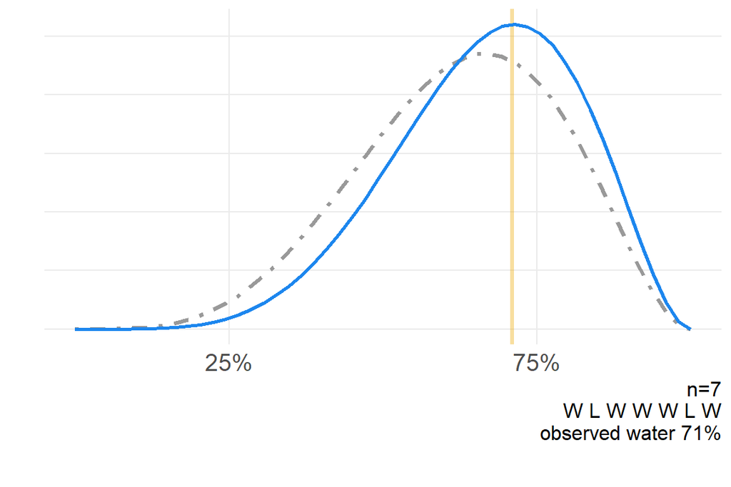

```r
n_7g <- ggplot(n_7, aes(p_water)) +
  geom_vline(xintercept=.71, size=1.2, color="darkgoldenrod2", alpha=.4) +
  geom_line(aes(y=prior), size=1.2, color="grey60", linetype="dotdash") +
  geom_line(aes(y=lik), size=1, color="dodgerblue2") +
  scale_x_continuous(breaks=c(.25,.75),
                     labels=percent) +
  theme(axis.text.y=element_blank()) +
  labs(x="",
       y="",
       #title="W L W W W L W",
       caption="n=7\nW L W W W L W\nobserved water 71%") +
  theme(plot.caption = element_text(vjust=10))

n_7g
```

[figure not shown]

```r
n_1g + n_2g + n_3g + n_4g + n_5g + n_6g + n_7g
```

```r
d
```

```
## Error in eval(expr, envir, enclos): object 'd' not found
```

```r
n_8 <- data.frame(toss=rep("l", 50),
                  trials=rep(8,50),
                  success=rep(5,50),
                  p_water = seq(0,1,length.out=50),
                  prior=n_7$lik) %>%
  mutate(lik_raw = dbinom(success,trials,p_water),
         lik=lik_raw / sum(lik_raw))

n_8
```

Table 3.2:

| toss | trials | success | p_water | prior | lik_raw | lik |
| --- | --- | --- | --- | --- | --- | --- |
| l | 8 | 5 | 0 | 0 | 0 | 0 |
| l | 8 | 5 | 0.0204 | 1.16e-08 | 1.86e-07 | 3.42e-08 |
| l | 8 | 5 | 0.0408 | 3.57e-07 | 5.6e-06 | 1.03e-06 |
| l | 8 | 5 | 0.0612 | 2.6e-06 | 3.99e-05 | 7.32e-06 |
| l | 8 | 5 | 0.0816 | 1.05e-05 | 0.000157 | 2.89e-05 |
| l | 8 | 5 | 0.102 | 3.06e-05 | 0.000449 | 8.24e-05 |
| l | 8 | 5 | 0.122 | 7.27e-05 | 0.00104 | 0.000191 |
| l | 8 | 5 | 0.143 | 0.00015 | 0.0021 | 0.000385 |
| l | 8 | 5 | 0.163 | 0.000278 | 0.00381 | 0.000699 |
| l | 8 | 5 | 0.184 | 0.000478 | 0.00637 | 0.00117 |
| l | 8 | 5 | 0.204 | 0.000769 | 0.01 | 0.00184 |
| l | 8 | 5 | 0.224 | 0.00118 | 0.0149 | 0.00274 |
| l | 8 | 5 | 0.245 | 0.00172 | 0.0212 | 0.0039 |
| l | 8 | 5 | 0.265 | 0.00243 | 0.0292 | 0.00536 |
| l | 8 | 5 | 0.286 | 0.00333 | 0.0389 | 0.00714 |
| l | 8 | 5 | 0.306 | 0.00444 | 0.0503 | 0.00924 |
| l | 8 | 5 | 0.327 | 0.00577 | 0.0635 | 0.0117 |
| l | 8 | 5 | 0.347 | 0.00735 | 0.0784 | 0.0144 |
| l | 8 | 5 | 0.367 | 0.00918 | 0.0949 | 0.0174 |
| l | 8 | 5 | 0.388 | 0.0113 | 0.113 | 0.0207 |
| l | 8 | 5 | 0.408 | 0.0136 | 0.132 | 0.0242 |
| l | 8 | 5 | 0.429 | 0.0162 | 0.151 | 0.0277 |
| l | 8 | 5 | 0.449 | 0.019 | 0.171 | 0.0314 |
| l | 8 | 5 | 0.469 | 0.022 | 0.191 | 0.035 |
| l | 8 | 5 | 0.49 | 0.0252 | 0.21 | 0.0385 |
| l | 8 | 5 | 0.51 | 0.0284 | 0.227 | 0.0418 |
| l | 8 | 5 | 0.531 | 0.0318 | 0.244 | 0.0447 |
| l | 8 | 5 | 0.551 | 0.0351 | 0.257 | 0.0473 |
| l | 8 | 5 | 0.571 | 0.0384 | 0.269 | 0.0493 |
| l | 8 | 5 | 0.592 | 0.0415 | 0.277 | 0.0508 |
| l | 8 | 5 | 0.612 | 0.0443 | 0.281 | 0.0516 |
| l | 8 | 5 | 0.633 | 0.0469 | 0.281 | 0.0517 |
| l | 8 | 5 | 0.653 | 0.049 | 0.278 | 0.051 |
| l | 8 | 5 | 0.673 | 0.0506 | 0.27 | 0.0496 |
| l | 8 | 5 | 0.694 | 0.0517 | 0.258 | 0.0475 |
| l | 8 | 5 | 0.714 | 0.052 | 0.243 | 0.0446 |
| l | 8 | 5 | 0.735 | 0.0517 | 0.224 | 0.0411 |
| l | 8 | 5 | 0.755 | 0.0505 | 0.202 | 0.0371 |
| l | 8 | 5 | 0.776 | 0.0485 | 0.178 | 0.0326 |
| l | 8 | 5 | 0.796 | 0.0456 | 0.152 | 0.0279 |
| l | 8 | 5 | 0.816 | 0.0419 | 0.126 | 0.0231 |
| l | 8 | 5 | 0.837 | 0.0375 | 0.1 | 0.0184 |
| l | 8 | 5 | 0.857 | 0.0324 | 0.0755 | 0.0139 |
| l | 8 | 5 | 0.878 | 0.0268 | 0.0535 | 0.00983 |
| l | 8 | 5 | 0.898 | 0.0208 | 0.0347 | 0.00638 |
| l | 8 | 5 | 0.918 | 0.0149 | 0.0199 | 0.00366 |
| l | 8 | 5 | 0.939 | 0.00937 | 0.00937 | 0.00172 |
| l | 8 | 5 | 0.959 | 0.00464 | 0.00309 | 0.000568 |
| l | 8 | 5 | 0.98 | 0.00129 | 0.000429 | 7.89e-05 |
| l | 8 | 5 | 1 | 0 | 0 | 0 |

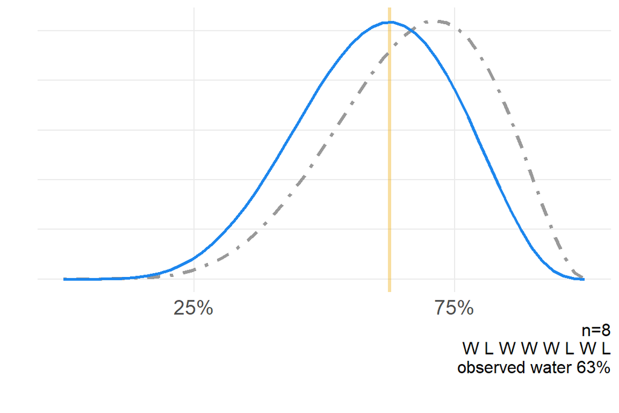

```r
n_8g <- ggplot(n_8, aes(p_water)) +
  geom_vline(xintercept=.625, size=1.2, color="darkgoldenrod2", alpha=.4) +
  geom_line(aes(y=prior), size=1.2, color="grey60", linetype="dotdash") +
  geom_line(aes(y=lik), size=1, color="dodgerblue2") +
  scale_x_continuous(breaks=c(.25,.75),
                     labels=percent) +
  theme(axis.text.y=element_blank()) +
  labs(x="",
       y="",
       #title="W L W W W L W L",
       caption="n=8\nW L W W W L W L\nobserved water 63%") +
  theme(plot.caption = element_text(vjust=10))

n_8g
```

[figure not shown]

```r
n_1g + n_2g + n_3g + n_4g + n_5g + n_6g + n_7g + n_8g
```

```r
d
```

```
## Error in eval(expr, envir, enclos): object 'd' not found
```

```r
n_9 <- data.frame(toss=rep("w", 50),
                  trials=rep(9,50),
                  success=rep(6,50),
                  p_water = seq(0,1,length.out=50),
                  prior=n_8$lik) %>%
  mutate(lik_raw = dbinom(success,trials,p_water),
         lik=lik_raw / sum(lik_raw))

n_9
```

Table 3.2:

| toss | trials | success | p_water | prior | lik_raw | lik |
| --- | --- | --- | --- | --- | --- | --- |
| w | 9 | 6 | 0 | 0 | 0 | 0 |
| w | 9 | 6 | 0.0204 | 3.42e-08 | 5.7e-09 | 1.16e-09 |
| w | 9 | 6 | 0.0408 | 1.03e-06 | 3.43e-07 | 7e-08 |
| w | 9 | 6 | 0.0612 | 7.32e-06 | 3.66e-06 | 7.47e-07 |
| w | 9 | 6 | 0.0816 | 2.89e-05 | 1.93e-05 | 3.93e-06 |
| w | 9 | 6 | 0.102 | 8.24e-05 | 6.87e-05 | 1.4e-05 |
| w | 9 | 6 | 0.122 | 0.000191 | 0.000191 | 3.91e-05 |
| w | 9 | 6 | 0.143 | 0.000385 | 0.00045 | 9.18e-05 |
| w | 9 | 6 | 0.163 | 0.000699 | 0.000932 | 0.00019 |
| w | 9 | 6 | 0.184 | 0.00117 | 0.00175 | 0.000358 |
| w | 9 | 6 | 0.204 | 0.00184 | 0.00306 | 0.000624 |
| w | 9 | 6 | 0.224 | 0.00274 | 0.00501 | 0.00102 |
| w | 9 | 6 | 0.245 | 0.0039 | 0.0078 | 0.00159 |
| w | 9 | 6 | 0.265 | 0.00536 | 0.0116 | 0.00237 |
| w | 9 | 6 | 0.286 | 0.00714 | 0.0167 | 0.0034 |
| w | 9 | 6 | 0.306 | 0.00924 | 0.0231 | 0.00471 |
| w | 9 | 6 | 0.327 | 0.0117 | 0.0311 | 0.00635 |
| w | 9 | 6 | 0.347 | 0.0144 | 0.0408 | 0.00833 |
| w | 9 | 6 | 0.367 | 0.0174 | 0.0523 | 0.0107 |
| w | 9 | 6 | 0.388 | 0.0207 | 0.0655 | 0.0134 |
| w | 9 | 6 | 0.408 | 0.0242 | 0.0805 | 0.0164 |
| w | 9 | 6 | 0.429 | 0.0277 | 0.0971 | 0.0198 |
| w | 9 | 6 | 0.449 | 0.0314 | 0.115 | 0.0235 |
| w | 9 | 6 | 0.469 | 0.035 | 0.134 | 0.0274 |
| w | 9 | 6 | 0.49 | 0.0385 | 0.154 | 0.0314 |
| w | 9 | 6 | 0.51 | 0.0418 | 0.174 | 0.0355 |
| w | 9 | 6 | 0.531 | 0.0447 | 0.194 | 0.0396 |
| w | 9 | 6 | 0.551 | 0.0473 | 0.213 | 0.0434 |
| w | 9 | 6 | 0.571 | 0.0493 | 0.23 | 0.047 |
| w | 9 | 6 | 0.592 | 0.0508 | 0.245 | 0.0501 |
| w | 9 | 6 | 0.612 | 0.0516 | 0.258 | 0.0526 |
| w | 9 | 6 | 0.633 | 0.0517 | 0.267 | 0.0545 |
| w | 9 | 6 | 0.653 | 0.051 | 0.272 | 0.0555 |
| w | 9 | 6 | 0.673 | 0.0496 | 0.273 | 0.0557 |
| w | 9 | 6 | 0.694 | 0.0475 | 0.269 | 0.0549 |
| w | 9 | 6 | 0.714 | 0.0446 | 0.26 | 0.0531 |
| w | 9 | 6 | 0.735 | 0.0411 | 0.247 | 0.0503 |
| w | 9 | 6 | 0.755 | 0.0371 | 0.229 | 0.0467 |
| w | 9 | 6 | 0.776 | 0.0326 | 0.207 | 0.0422 |
| w | 9 | 6 | 0.796 | 0.0279 | 0.182 | 0.037 |
| w | 9 | 6 | 0.816 | 0.0231 | 0.154 | 0.0314 |
| w | 9 | 6 | 0.837 | 0.0184 | 0.125 | 0.0256 |
| w | 9 | 6 | 0.857 | 0.0139 | 0.0971 | 0.0198 |
| w | 9 | 6 | 0.878 | 0.00983 | 0.0704 | 0.0144 |
| w | 9 | 6 | 0.898 | 0.00638 | 0.0468 | 0.00955 |
| w | 9 | 6 | 0.918 | 0.00366 | 0.0274 | 0.00559 |
| w | 9 | 6 | 0.939 | 0.00172 | 0.0132 | 0.00269 |
| w | 9 | 6 | 0.959 | 0.000568 | 0.00445 | 0.000908 |
| w | 9 | 6 | 0.98 | 7.89e-05 | 0.000631 | 0.000129 |
| w | 9 | 6 | 1 | 0 | 0 | 0 |

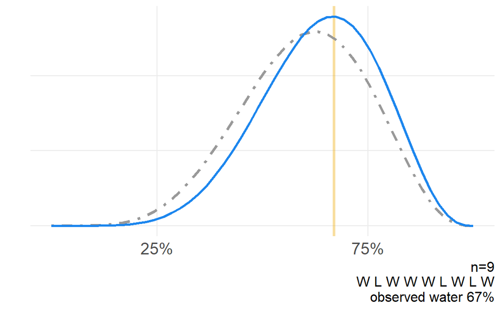

```r
n_9g <- ggplot(n_9, aes(p_water)) +
  geom_vline(xintercept=.67, size=1.2, color="darkgoldenrod2", alpha=.4) +
  geom_line(aes(y=prior), size=1.2, color="grey60", linetype="dotdash") +
  geom_line(aes(y=lik), size=1, color="dodgerblue2") +
  scale_x_continuous(breaks=c(.25,.75),
                     labels=percent) +
  theme(axis.text.y=element_blank()) +
  labs(x="",
       y="",
       #title="W L W W W L W L W",
       caption="n=9
       W L W W W L W L W
       observed water 67%") +
  theme(plot.caption = element_text(vjust=10))

n_9g
```

[figure not shown]

```r
out <- n_1g + n_2g + n_3g + n_4g + n_5g + n_6g + n_7g + n_8g + n_9g

out
```

```r
ggsave(out,
       file="viz/Bayesian updating.png",
       device="png",
       type="cairo",
       height=6,
       width=8)
```

```r
set.seed(54)

bin_mod <- data.frame(prior=1,
                      param = round(seq(0,1,length.out=20),3)) %>%
  mutate(lik = dbinom(6, 9, param),
         unstd.posterior = lik*prior,
         posterior = unstd.posterior / sum(unstd.posterior))

bin_mod
```

Table 3.3:

| prior | param | lik | unstd.posterior | posterior |
| --- | --- | --- | --- | --- |
| 1 | 0 | 0 | 0 | 0 |
| 1 | 0.053 | 1.58e-06 | 1.58e-06 | 8.32e-07 |
| 1 | 0.105 | 8.07e-05 | 8.07e-05 | 4.25e-05 |
| 1 | 0.158 | 0.00078 | 0.00078 | 0.00041 |
| 1 | 0.211 | 0.00364 | 0.00364 | 0.00192 |
| 1 | 0.263 | 0.0111 | 0.0111 | 0.00585 |
| 1 | 0.316 | 0.0268 | 0.0268 | 0.0141 |
| 1 | 0.368 | 0.0527 | 0.0527 | 0.0277 |
| 1 | 0.421 | 0.0908 | 0.0908 | 0.0478 |
| 1 | 0.474 | 0.139 | 0.139 | 0.0729 |
| 1 | 0.526 | 0.189 | 0.189 | 0.0997 |
| 1 | 0.579 | 0.236 | 0.236 | 0.124 |
| 1 | 0.632 | 0.267 | 0.267 | 0.14 |
| 1 | 0.684 | 0.271 | 0.271 | 0.143 |
| 1 | 0.737 | 0.245 | 0.245 | 0.129 |
| 1 | 0.789 | 0.19 | 0.19 | 0.1 |
| 1 | 0.842 | 0.118 | 0.118 | 0.0621 |
| 1 | 0.895 | 0.05 | 0.05 | 0.0263 |
| 1 | 0.947 | 0.00902 | 0.00902 | 0.00475 |
| 1 | 1 | 0 | 0 | 0 |

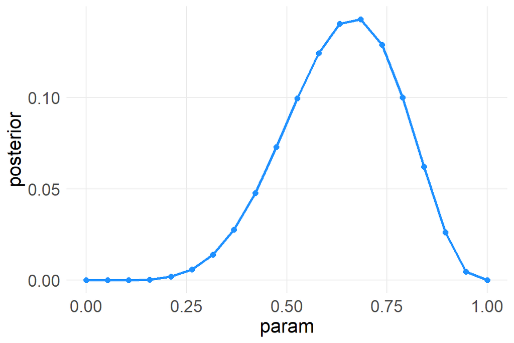

```r
ggplot(bin_mod, aes(param, posterior)) +
  geom_point(color="dodgerblue", size=2) +
  geom_line(color="dodgerblue", size=1)
```

```r
bin_mod2 <- data.frame(prior=1,
                      param = round(seq(0,1,length.out=20),3)) %>%
  mutate(prior = ifelse(param < 0.5 , 0 , 1),
         lik = dbinom(6, 9, param),
         unstd.posterior = lik*prior,
         posterior = unstd.posterior / sum(unstd.posterior),
         prev_posterior = bin_mod$posterior)

bin_mod2
```

Table 3.4:

| prior | param | lik | unstd.posterior | posterior | prev_posterior |
| --- | --- | --- | --- | --- | --- |
| 0 | 0 | 0 | 0 | 0 | 0 |
| 0 | 0.053 | 1.58e-06 | 0 | 0 | 8.32e-07 |
| 0 | 0.105 | 8.07e-05 | 0 | 0 | 4.25e-05 |
| 0 | 0.158 | 0.00078 | 0 | 0 | 0.00041 |
| 0 | 0.211 | 0.00364 | 0 | 0 | 0.00192 |
| 0 | 0.263 | 0.0111 | 0 | 0 | 0.00585 |
| 0 | 0.316 | 0.0268 | 0 | 0 | 0.0141 |
| 0 | 0.368 | 0.0527 | 0 | 0 | 0.0277 |
| 0 | 0.421 | 0.0908 | 0 | 0 | 0.0478 |
| 0 | 0.474 | 0.139 | 0 | 0 | 0.0729 |
| 1 | 0.526 | 0.189 | 0.189 | 0.12 | 0.0997 |
| 1 | 0.579 | 0.236 | 0.236 | 0.15 | 0.124 |
| 1 | 0.632 | 0.267 | 0.267 | 0.169 | 0.14 |
| 1 | 0.684 | 0.271 | 0.271 | 0.172 | 0.143 |
| 1 | 0.737 | 0.245 | 0.245 | 0.155 | 0.129 |
| 1 | 0.789 | 0.19 | 0.19 | 0.121 | 0.1 |
| 1 | 0.842 | 0.118 | 0.118 | 0.0749 | 0.0621 |
| 1 | 0.895 | 0.05 | 0.05 | 0.0317 | 0.0263 |
| 1 | 0.947 | 0.00902 | 0.00902 | 0.00572 | 0.00475 |
| 1 | 1 | 0 | 0 | 0 | 0 |

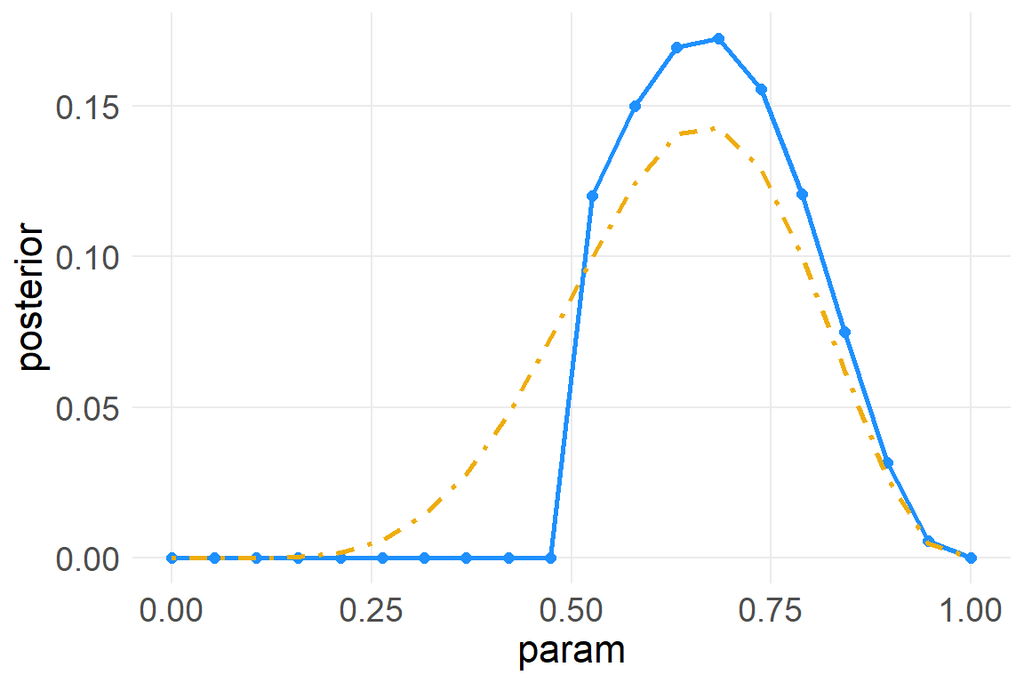

```r
ggplot(bin_mod2, aes(param, posterior)) +
  geom_point(color="dodgerblue", size=2) +
  geom_line(color="dodgerblue", size=1) +
  geom_line(aes(y=prev_posterior), color="darkgoldenrod2", size=1, linetype="dotdash")
```

```r
bin_mod3 <- data.frame(prior=1,
                      param = round(seq(0,1,length.out=20),3)) %>%
  mutate(prior = exp( -5*abs(param - 0.5)),
         lik = dbinom(6, 9, param),
         unstd.posterior = lik*prior,
         posterior = unstd.posterior / sum(unstd.posterior),
         prev_posterior = bin_mod2$posterior,
         prev_posterior2 = bin_mod$posterior)

bin_mod3
```

Table 3.5:

| prior | param | lik | unstd.posterior | posterior | prev_posterior | prev_posterior2 |
| --- | --- | --- | --- | --- | --- | --- |
| 0.0821 | 0 | 0 | 0 | 0 | 0 | 0 |
| 0.107 | 0.053 | 1.58e-06 | 1.69e-07 | 1.79e-07 | 0 | 8.32e-07 |
| 0.139 | 0.105 | 8.07e-05 | 1.12e-05 | 1.18e-05 | 0 | 4.25e-05 |
| 0.181 | 0.158 | 0.00078 | 0.000141 | 0.000149 | 0 | 0.00041 |
| 0.236 | 0.211 | 0.00364 | 0.000858 | 0.000908 | 0 | 0.00192 |
| 0.306 | 0.263 | 0.0111 | 0.0034 | 0.0036 | 0 | 0.00585 |
| 0.399 | 0.316 | 0.0268 | 0.0107 | 0.0113 | 0 | 0.0141 |
| 0.517 | 0.368 | 0.0527 | 0.0272 | 0.0288 | 0 | 0.0277 |
| 0.674 | 0.421 | 0.0908 | 0.0612 | 0.0647 | 0 | 0.0478 |
| 0.878 | 0.474 | 0.139 | 0.122 | 0.129 | 0 | 0.0729 |
| 0.878 | 0.526 | 0.189 | 0.166 | 0.176 | 0.12 | 0.0997 |
| 0.674 | 0.579 | 0.236 | 0.159 | 0.168 | 0.15 | 0.124 |
| 0.517 | 0.632 | 0.267 | 0.138 | 0.146 | 0.169 | 0.14 |
| 0.399 | 0.684 | 0.271 | 0.108 | 0.114 | 0.172 | 0.143 |
| 0.306 | 0.737 | 0.245 | 0.0749 | 0.0792 | 0.155 | 0.129 |
| 0.236 | 0.789 | 0.19 | 0.0449 | 0.0475 | 0.121 | 0.1 |
| 0.181 | 0.842 | 0.118 | 0.0214 | 0.0226 | 0.0749 | 0.0621 |
| 0.139 | 0.895 | 0.05 | 0.00694 | 0.00733 | 0.0317 | 0.0263 |
| 0.107 | 0.947 | 0.00902 | 0.000965 | 0.00102 | 0.00572 | 0.00475 |
| 0.0821 | 1 | 0 | 0 | 0 | 0 | 0 |

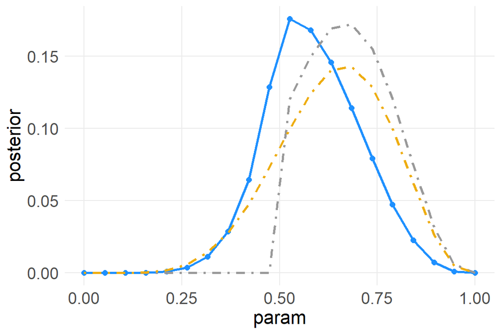

```r
ggplot(bin_mod3, aes(param, posterior)) +
  geom_point(color="dodgerblue", size=2) +
  geom_line(color="dodgerblue", size=1) +
  geom_line(aes(y=prev_posterior), color="grey60", size=1, linetype="dotdash") +
  geom_line(aes(y=prev_posterior2), color="darkgoldenrod2", size=1, linetype="dotdash")
```

```r
globe.qa <- map(
     alist(
          w ~ dbinom(9,p) ,  # binomial likelihood
          p ~ dunif(0,1)     # uniform prior
     ) ,
     data=list(w=6) )
```

[output not shown]

```r
# display summary of quadratic approximation
precis( globe.qa )
```

[output not shown]

```r
ggplot()
```

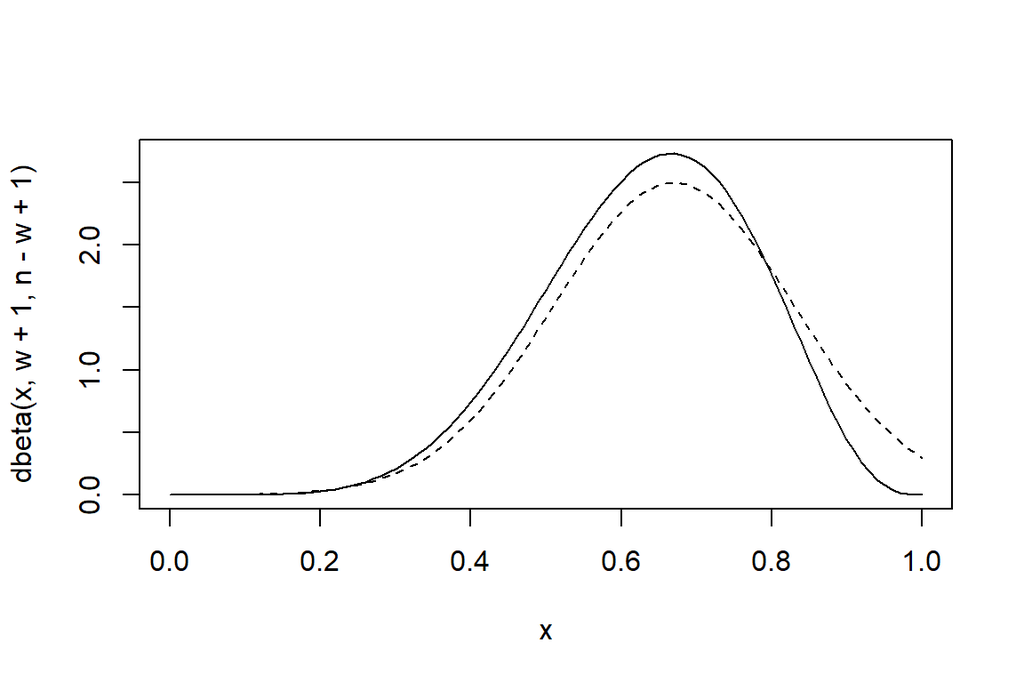

```r
## R code 2.7
# analytical calculation
w <- 6
n <- 9
curve( dbeta( x , w+1 , n-w+1 ) , from=0 , to=1 )
# quadratic approximation
curve( dnorm( x , 0.67 , 0.16 ) , lty=2 , add=TRUE )
```

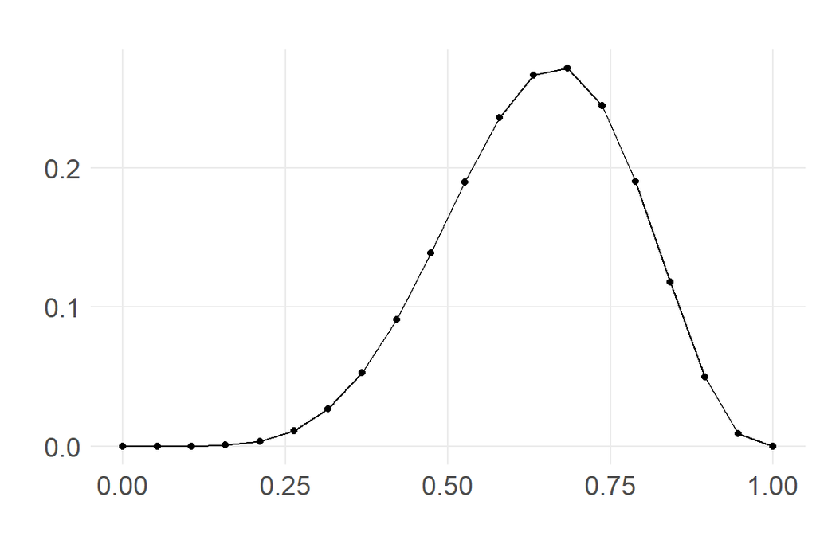

```r
ggplot(bin_mod, aes(param, lik)) +
  geom_point() +
  geom_line() +
  labs(x="",
       y="",
       title="")
```